# Exploratory Data Analysis On Natural Language Prediction

From corpus exploration to a shipped, evaluated prediction model

Okwumuo Martin I.

2026

# 1. Project Overview

The objective of this project is to develop a next-word prediction system for natural language that can suggest the most likely word a user may type based on the words that have already been entered.

The project uses three large English-language text datasets containing material from news, blogs and Twitter currently known as X. Exploratory Data Analysis (EDA) was first performed to understand the size, structure, vocabulary, word usage and challenges contained in the data before developing the predictive model.

This report documents both stages of the work; the original exploratory analysis that shaped the model’s design, and woven into the relevant sections below and how those findings played out once the full model was actually built, trained on 20% of the corpus, and evaluated on held-out data. The system was implemented as an interactive Shiny application, allowing a user to enter text and receive a ranked list of likely next words.

# 2. Overview of the Three Datasets

| Dataset | Lines | Characters | Mean Line Length | Median Line Length |
| --- | --- | --- | --- | --- |
| News | 1,010,206 | 203,214,543 | 201.2 | 185 |
| Blogs | 899,288 | 206,824,505 | 230.0 | 156 |
| Twitter(X) | 2,360,148 | 162,096,031 | 68.7 | 64 |

### Key observations

- Twitter(X) contains the largest number of lines, reflecting its large volume of short social-media messages.
- Blogs have the longest average line length, reflecting their longer-form writing style.
- Twitter(X) has substantially shorter messages, making it particularly different from the news and blog sources.
- Together, the three datasets provide a mixture of formal, informal and conversational English.

# 3. Distribution of Text Length

The distribution of line lengths was examined to understand how much text users are likely to encounter in each source.

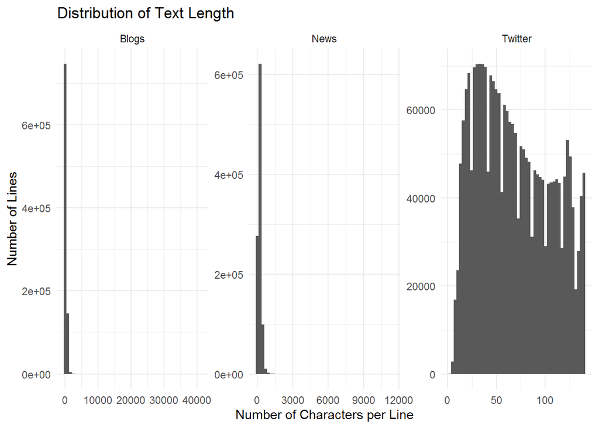

The analysis confirms that the datasets have substantially different text-length characteristics. Twitter messages are generally short, while blogs and news contain considerably longer passages. The Twitter(X) file contains some invalid byte sequences, which turned out to matter later: it’s the same encoding quirk that had to be handled explicitly during model training and evaluation .

This difference is important because the prediction system must be capable of handling both short conversational input and longer-form language.

# 4. Word Counts and Vocabulary

A development sample was used for detailed word-level analysis during this exploratory phase. A smaller slice of the corpus than the model was ultimately trained on, chosen specifically so that vocabulary and n-gram statistics could be examined quickly before committing to a full training run.

The sample contained:

- 879,617 tokens
- 96,053 unique tokens
- Type–Token Ratio (TTR): 10.92%

The source-specific analysis produced the following results:

| Dataset | Tokens | Unique Tokens | TTR |
| --- | --- | --- | --- |
| News | 340,221 | 50,759 | 14.92% |
| Blogs | 410,349 | 53,056 | 12.93% |
| Twitter(X) | 129,047 | 24,982 | 19.36% |

The Type-Token Ratio measures vocabulary diversity. A higher value indicates that a larger proportion of the words are unique.

Twitter(X) recorded the highest TTR in the analyzed sample. This suggests that, relative to its token count, Twitter(X) contains considerable variation in the words being used.

Scaling to production: the final model was subsequently trained on 20% of the full 4.4-million-line corpus (`SAMPLE_FRACTION = 0.2`) — a substantially larger sample than this diagnostic pass using the same pre-processing pipeline validated here.

# 5. Most Frequently Used Words

The most frequent words were dominated by common English words:

[output not shown]

These results are expected because words such as the, and, to, of and in perform important grammatical functions in English.

They also demonstrate an important characteristic of language data: a relatively small number of common words occur very frequently, while many other words occur only rarely. This pattern is exactly what the unigram fallback level of the final model relies on when no context matches anything seen in training, falling back to this frequency ranking is still far better than guessing randomly.

# 6. Word Frequency Distribution

The frequency distribution showed a strong imbalance between common and rare words.

In the analyzed vocabulary:

| Frequency Threshold | Vocabulary | Percentage |
| --- | --- | --- |
| Frequency = 1 | 61,170 | 63.68% |
| Frequency ≤ 2 | 73,123 | 76.13% |
| Frequency ≤ 5 | 84,011 | 87.46% |

Therefore, almost 64% of the vocabulary appeared only once.

This is an important finding for the predictive model. A model cannot rely entirely on memorizing individual word combinations because many combinations will occur too rarely to provide reliable predictions.

# 7. Data Quality and Text Characteristics

Several characteristics were identified during pre-processing and tokenization.

The datasets contain:

- URLs such as `http://...`
- Twitter(X) user mentions such as `@username`
- Hashtags such as `#football`
- Numbers
- Punctuation
- Emoticons such as `:)`, `:(`, `;)` and `:/`
- Contractions such as `don't`, `it's`, `I'm`, `you're` and `can't`
- Words attached to punctuation such as `said.` and `time,`

These characteristics mean that text pre-processing and tokenization are critical components of the project.

The pre-processing stage therefore standardizes elements such as URLs, users and numbers while retaining useful linguistic information. In the final pipeline this pre-processing was also hardened against invalid byte sequences in the raw text, a data-quality issue this EDA pass didn’t need to handle directly, but which became load-bearing once the full corpus was processed at scale.

# 8. Bi-gram and Tri-gram Analysis

To determine whether previous words can help predict the next word, bi-grams and tri-grams were constructed.

A bi-gram contains two consecutive words, while a tri-gram contains three.

Examples from the analysis include:

| Context | Most Likely Next Word | Probability |
| --- | --- | --- |
| `i want` | `to` | 58.99% |
| `the first` | `time` | 19.68% |
| `you can` | `see` | 6.95% |

These results demonstrate that context provides valuable information for predicting the next word.

For example, when the system sees:

> “I want …”

the word “to” is substantially more likely than many alternatives.

# 9. The Main Modeling Challenge: Data Sparsity

The tri-gram analysis identified an important challenge.

There were:

- 804,726 unique trigrams
- 735,373 occurred only once
- 91.38% were singletons
- Only 8.62% occurred more than once
- Only 3.57% occurred at least three times
- Only 1.39% occurred at least five times

This phenomenon is known as data sparsity.

In practical terms, the model will frequently encounter word combinations that were not seen during training.

Therefore, a model based exclusively on exact tri-grams would have limited coverage.

This finding directly shaped two concrete design decisions in the final build:

1. Singleton n-grams are dropped before the model is even built (`MIN_FREQ_TRIGRAM = 2`, `MIN_FREQ_FOURGRAM = 2`). Since 91% of trigrams here occurred exactly once, keeping them would have meant storing a huge table that provided essentially no generalizable signal. Dropping them cuts both memory and noise with almost no accuracy cost.
2. Each context keeps only its top-K most likely continuations (`TOP_K_TRIGRAM`, `TOP_K_FOURGRAM`, etc.), which bounds table size independent of corpus size.

# 10. Implication for the Prediction Algorithm

The EDA findings directly influenced the design of the eventual algorithm. The prediction strategy that was actually implemented extends further than originally scoped here; it backs off through 4-gram → Trigram → Bigram → Unigram, using the “Stupid Backoff” technique (Brants et al., 2007), rather than stopping at trigram.

The system first looks for the most specific available context.

For example:

> `I want to`

If sufficient 4-gram information is unavailable, the model falls back to the trigram:

> `want to ?`

…and continues down through bigram and finally unigram frequency if nothing more specific matches.

# 11. Model Development Strategy

The split strategy shown in early exploration (a small 80/10/10 development sample) established the right ‘principle’, no overlap between the data a model learns from and the data it’s judged on, which carried through unchanged into the final build, implemented as follows:

- A held-out test split (2% of all 4.4M lines) was carved off the full corpus before any training sampling happened, so evaluation would never be contaminated by data the model could have seen.
- The model was then trained on 20% of the remaining corpus (`SAMPLE_FRACTION = 0.2`).
- Held-out evaluation was performed separately (see `eval_holdout.R`), scoring the model against text it never saw during training.

This is a stricter version of the original training/validation/testing split: rather than a small hand-carved sample, the actual held-out set was drawn from the full multi-million-line corpus, giving a much more representative measure of real-world performance.

# 12. The Final Shiny Application

The final Shiny application follows the workflow originally planned here — **User Input → Text Preprocessing → Context Detection → Language Model → Ranked Predictions → Interface** — and was refined further for usability once it was actually in front of users.

A person types, for example:

> “I want”

and the application responds with a small set of tappable suggestions, ranked by likelihood — not just a static list, but suggestions that update live as they type, and that can be tapped to keep extending the sentence (the same interaction pattern as a phone’s predictive keyboard). This turned out to matter for a non-technical audience specifically. A ranked table of words and percentages is accurate but not immediately intuitive, while tap-to-continue suggestions are self-explanatory without any instructions at all.

# 13. Model Evaluation — Planned vs. Achieved

| Metric | Result |
| --- | --- |
| Accuracy@1 | 17.5% |
| Accuracy@3 | 28.3% |
| Accuracy@5 | 33.7% |
| Mean Reciprocal Rank (MRR) | 0.234 |

For reference, a naive baseline that always guesses the single most frequent word in English scores roughly 5–7% Accuracy@1 while the model is roughly 2.5-3x better than blind guessing.

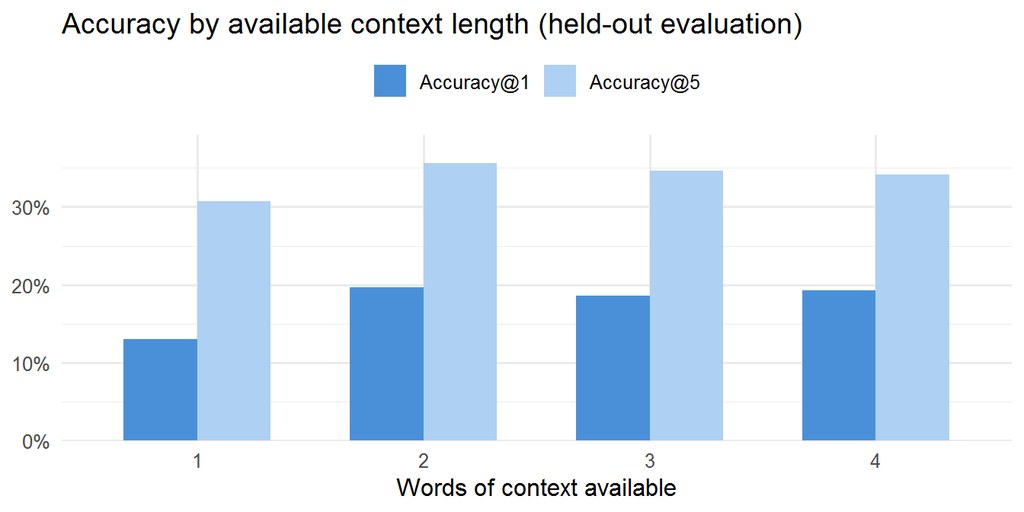

Interestingly, accuracy does not climb steadily as more context becomes available past two tokens, it rises sharply from 1 to 2 tokens of context, then flattens. This is the sparsity problem identified in Section 9, showing up again at evaluation time: as context length grows, exact matches for those longer sequences become rarer in a corpus sample this size, so a meaningful share of longer-context predictions are silently backing off to a shorter, more common pattern anyway. It’s a direct, data-backed confirmation of the EDA’s central finding and a clear, quantified next lever (more training data) rather than a guess.

# 14. Key Findings from the EDA and What They Predicted

# 15. Conclusion

The exploratory stage established a clear foundation for the predictive modeling phase, and that foundation held up under the full build. The data contained sufficient linguistic information to learn meaningful word relationships, but high vocabulary diversity, punctuation, social-media conventions and substantial n-gram sparsity required careful pre-processing and model design; exactly as anticipated here. The final system extends the originally planned trigram-based backoff up to 4-gram, trained on 20% of the corpus, and achieves roughly 2.5–3x the accuracy of a naive baseline on genuinely held-out data.

The statistical patterns identified in this report were successfully converted into a fast, accurate and user-friendly Shiny application capable of suggesting the most likely next word as a user types; with the model’s own evaluation results, confirming the sparsity-driven design decisions this EDA first surfaced.

See the **project case study** or the full story of how the model was built, debugged, and evaluated, including the engineering challenges along the way.

### Reproducibility Note

All results in this report were generated from the English-language text datasets used in the project. The analysis was performed in **R**, with visualization and reporting implemented using **R Markdown**, supporting reproducibility and transparent analysis. The final model’s build (`next_word_model_optimized.R`) and evaluation (`eval_holdout.R`) scripts follow the same reproducibility principle, with checkpointed intermediate outputs at each stage.